# Simple Harmonic Motion Shiny Appplication

27 October 2016

## Simple Harmonic Motion

Simple harmonic motion can be demonstrated using a mass attached to a spring that is initially displacing and released to generate a spring force onto the mass, causing a type of periodic motion or oscillation.

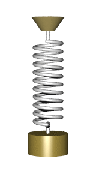

The mass weight, spring strength and damping clearly effect the motion, but in what way? A Shiny application has been developed to allow you to explore the change in frequency given changes in mass, spring force and damping factor.

gif by Svjo (Own work) [CC BY-SA 3.0 (http://creativecommons.org/licenses/by-sa/3.0)]

## Equation of Simple Harmonic Motion

The Shiny Application uses the Simple Harmonic Motion equation:

x = Acos(wt + $α$), where

- x is the mass's displacement (in metres)
- A is the starting Amplitude (in metres)
- t is elapsed time (in seconds)
- $α$ is the phase shift (in radians)
- w is the angular displacement (in radians)

- m is mass of the weight (in kg)
- k is the spring force (in N/m)

## Example Application Output

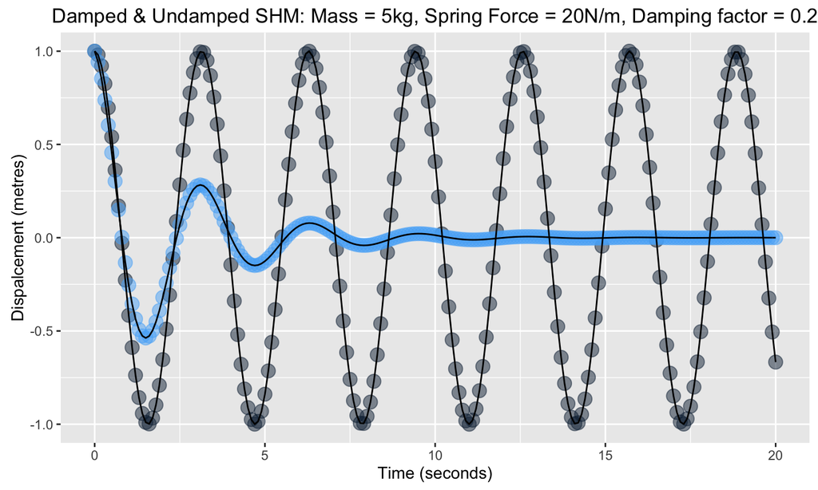